# 1. Which client/dataset did you select and why?

Client: SportsStats

SportsStats is a sports analysis firm partnering with local news and elite personal trainers to provide “interesting” insights to help their partners. Insights could be patterns/trends highlighting certain groups/events/countries, etc. for the purpose of developing a news story or discovering key health insights.

The data set being used: Olympics Dataset - 120 years of data

I selected the SportsStats client set as I have always had an interest in sports and being able to use the skills I learned throughout this course to dive deeper into sports related data is very appealing.

```python
import pandas as pd
from pandasql import sqldf
pysqldf = lambda q: sqldf(q, globals())
```

```python
athlete_events = pd.read_csv(r'C:\Users\Shay\Documents\SQL _Data_Science\Captstone_Project\athlete_events.csv')
%store athlete_events
```

```
Stored 'athlete_events' (DataFrame)
```

```python
noc_regions = pd.read_csv(r'C:\Users\Shay\Documents\SQL _Data_Science\Captstone_Project\noc_regions.csv')
```

```python
athlete_events.head()
```

|  | ID | Name | Sex | Age | Height | Weight | Team | NOC | Games | Year | Season | City | Sport | Event | Medal |
| --- | --- | --- | --- | --- | --- | --- | --- | --- | --- | --- | --- | --- | --- | --- | --- |
| 0 | 1 | A Dijiang | M | 24.0 | 180.0 | 80.0 | China | CHN | 1992 Summer | 1992 | Summer | Barcelona | Basketball | Basketball Men's Basketball | NaN |
| 1 | 2 | A Lamusi | M | 23.0 | 170.0 | 60.0 | China | CHN | 2012 Summer | 2012 | Summer | London | Judo | Judo Men's Extra-Lightweight | NaN |
| 2 | 3 | Gunnar Nielsen Aaby | M | 24.0 | NaN | NaN | Denmark | DEN | 1920 Summer | 1920 | Summer | Antwerpen | Football | Football Men's Football | NaN |
| 3 | 4 | Edgar Lindenau Aabye | M | 34.0 | NaN | NaN | Denmark/Sweden | DEN | 1900 Summer | 1900 | Summer | Paris | Tug-Of-War | Tug-Of-War Men's Tug-Of-War | Gold |
| 4 | 5 | Christine Jacoba Aaftink | F | 21.0 | 185.0 | 82.0 | Netherlands | NED | 1988 Winter | 1988 | Winter | Calgary | Speed Skating | Speed Skating Women's 500 metres | NaN |

```python
noc_regions.head()
```

|  | NOC | region | notes |
| --- | --- | --- | --- |
| 0 | AFG | Afghanistan | NaN |
| 1 | AHO | Curacao | Netherlands Antilles |
| 2 | ALB | Albania | NaN |
| 3 | ALG | Algeria | NaN |
| 4 | AND | Andorra | NaN |

```python
athlete_events.isnull().sum()
```

```
ID             0
Name           0
Sex            0
Age         9474
Height     60171
Weight     62875
Team           0
NOC            0
Games          0
Year           0
Season         0
City           0
Sport          0
Event          0
Medal     231333
dtype: int64
```

Looking at the null values in each category, we have a significant number of nulls within 'Age', 'Height' and 'Weight' The nulls under the 'Medal' column is expected as not every athlete is going to receive a medal.

```python
pysqldf('''SELECT COUNT(*) Total
            FROM athlete_events''')
```

|  | Total |
| --- | --- |
| 0 | 271116 |

First I am going to split the events into two categories since we are working with data from the Olympics, 'Summer' and 'Winter'.

```python
summer_games = pysqldf('''SELECT ID, Name, Sex, Age, Height, Weight, Team, NOC, Games, Year, Season, City, Sport, Event, Medal
                        FROM athlete_events
                        WHERE Season = "Summer"''')
%store summer_games
```

```
Stored 'summer_games' (DataFrame)
```

```python
summer_games.head()
```

|  | ID | Name | Sex | Age | Height | Weight | Team | NOC | Games | Year | Season | City | Sport | Event | Medal |
| --- | --- | --- | --- | --- | --- | --- | --- | --- | --- | --- | --- | --- | --- | --- | --- |
| 0 | 1 | A Dijiang | M | 24.0 | 180.0 | 80.0 | China | CHN | 1992 Summer | 1992 | Summer | Barcelona | Basketball | Basketball Men's Basketball | None |
| 1 | 2 | A Lamusi | M | 23.0 | 170.0 | 60.0 | China | CHN | 2012 Summer | 2012 | Summer | London | Judo | Judo Men's Extra-Lightweight | None |
| 2 | 3 | Gunnar Nielsen Aaby | M | 24.0 | NaN | NaN | Denmark | DEN | 1920 Summer | 1920 | Summer | Antwerpen | Football | Football Men's Football | None |
| 3 | 4 | Edgar Lindenau Aabye | M | 34.0 | NaN | NaN | Denmark/Sweden | DEN | 1900 Summer | 1900 | Summer | Paris | Tug-Of-War | Tug-Of-War Men's Tug-Of-War | Gold |
| 4 | 8 | Cornelia "Cor" Aalten (-Strannood) | F | 18.0 | 168.0 | NaN | Netherlands | NED | 1932 Summer | 1932 | Summer | Los Angeles | Athletics | Athletics Women's 100 metres | None |

```python
winter_games = pysqldf('''SELECT ID, Name, Sex, Age, Height, Weight, Team, NOC, Games, Year, Season, City, Sport, Event, Medal
                        FROM athlete_events
                        WHERE Season = "Winter"''')
%store winter_games
```

```
Stored 'winter_games' (DataFrame)
```

```python
winter_games.head()
```

|  | ID | Name | Sex | Age | Height | Weight | Team | NOC | Games | Year | Season | City | Sport | Event | Medal |
| --- | --- | --- | --- | --- | --- | --- | --- | --- | --- | --- | --- | --- | --- | --- | --- |
| 0 | 5 | Christine Jacoba Aaftink | F | 21.0 | 185.0 | 82.0 | Netherlands | NED | 1988 Winter | 1988 | Winter | Calgary | Speed Skating | Speed Skating Women's 500 metres | None |
| 1 | 5 | Christine Jacoba Aaftink | F | 21.0 | 185.0 | 82.0 | Netherlands | NED | 1988 Winter | 1988 | Winter | Calgary | Speed Skating | Speed Skating Women's 1,000 metres | None |
| 2 | 5 | Christine Jacoba Aaftink | F | 25.0 | 185.0 | 82.0 | Netherlands | NED | 1992 Winter | 1992 | Winter | Albertville | Speed Skating | Speed Skating Women's 500 metres | None |
| 3 | 5 | Christine Jacoba Aaftink | F | 25.0 | 185.0 | 82.0 | Netherlands | NED | 1992 Winter | 1992 | Winter | Albertville | Speed Skating | Speed Skating Women's 1,000 metres | None |
| 4 | 5 | Christine Jacoba Aaftink | F | 27.0 | 185.0 | 82.0 | Netherlands | NED | 1994 Winter | 1994 | Winter | Lillehammer | Speed Skating | Speed Skating Women's 500 metres | None |

# ERD

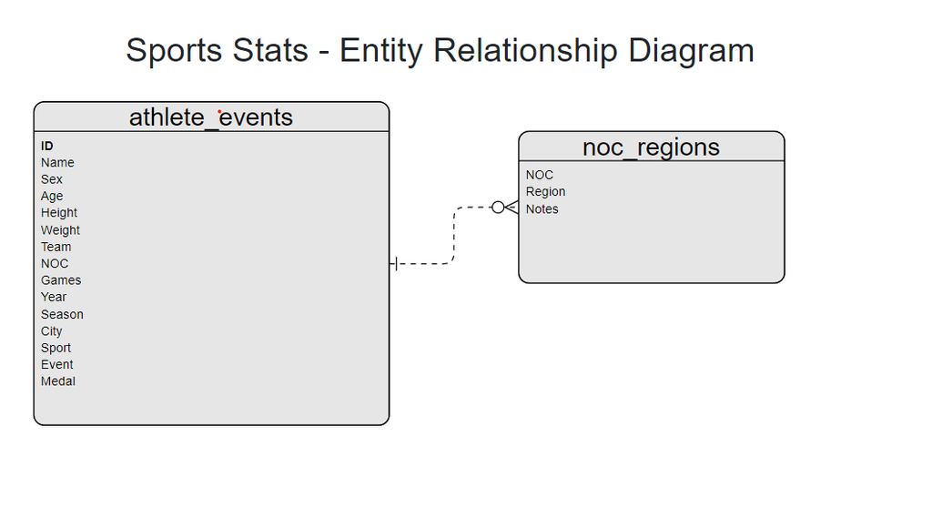

```python
from IPython.display import Image
Image(filename = r"C:\Users\Shay\Documents\SQL _Data_Science\Captstone_Project\ERD.png", width = 800, height = 400)
```

# Questions

Question 1: Is there more men or women competing in the Olympics, how has this changed over time

Question 2: Countries with the most medals and how they compare between Summer and Winter

Question 3: Age distribution, oldest and youngest Olympians

# Hypothesis

1: I would think there are more men competing in the Olypmics currently but I am very interested in seeing how this has changed overtime and would think in current years it will be a lot more evenly divided.

2: Countries with the most medals are presuming to be the largest countries by population. e.g USA, China etc.

3: I would Imagine the age gap would be quite significant and will be interesting to see which sports they are most divided by.

# Approach

1: First step is to review the table to get familiar with the data. I then ran a simple SQL query to get the total counts of males and females that have ever participated. I then declared a variable to store all of the info on males and another variable to store all the info on females using CAST, CASE and SUM functions to tally up the total number of males and femalesso I can visualize it.

I created a simple line chart to take a look at the data and see how the male/female participation rates have changed over time, once I plotted the graph it was difficult to read and understand as the numbers significantly dropped every 2 years for the winter Olympics and then spiked back up for the Summer Olpympics so it was difficult to grasp the actual difference between males and females.

I then split this out into two categories, participation for Summer Olympics and for Winter Olympics. Once I plotted the graphs broken out it was much easier to read and its easy to tell that there was a huge gap in gender participation in the early years but since the 1980 there has been a steady climb in female participants so eventually this should become very close.

2: I wanted to see the countries with the most medals won over the entire Olympics period (this dataset covers 120 years of data). As expected in my hypothesis USA had a signifcant lead over other countries.

I then broke it down to see the Summer and Winter figures. Once again as expected for Summer games it was USA leading the pack. The winter games were led by Canada with USA coming in second and then followed by Scandavian countries such as Norway, Sweeden and Finland which is expected for the Winter games.

3: This question was a lot easier but it was something that I was interested in knowing. I simply assigned a variable of ages and ran a SQL query to return all the ages and the count of each of these ages and then grouped by ages. I then plotted this onto a line chart as its always easier to get an understanding of your data when you can visualize it.

# Question 1:

Question 1: Is there more men or women competing in the Olympics, how has this changed over time

```python
pysqldf('''SELECT Sex, COUNT(Sex)
            FROM athlete_events
            WHERE Year >= 2000
            GROUP BY Sex''')
```

|  | Sex | COUNT(Sex) |
| --- | --- | --- |
| 0 | F | 36040 |
| 1 | M | 49218 |

As expected there are recently more men competing in the Olumpics compared to women but lets take a look at how this has changed over time

```python
male = pysqldf('''SELECT Year,
                        CAST(SUM(CASE WHEN Sex = 'M' THEN 1 ELSE 0 END) AS INT) Male
                        FROM athlete_events
                        GROUP BY year''')

male.tail()
%store male
```

```
Stored 'male' (DataFrame)
```

```python
female = pysqldf('''SELECT year,
                            CAST(SUM(CASE WHEN Sex = 'F' THEN 1 ELSE 0 END) AS INT) Female
                            FROM athlete_events
                            GROUP BY year''')

female.tail()
%store female
```

```
Stored 'female' (DataFrame)
```

```python
pip install matplotlib
```

```python
import matplotlib as mpl
import matplotlib.pyplot as plt
import numpy as np
```

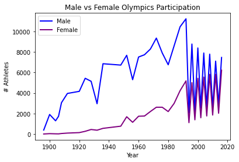

```python
plt.plot(male.Year, male.Male, marker='', color='blue', linewidth=2, label='Male')
plt.plot(female.Year, female.Female, marker='', color='purple', linewidth=2, label='Female')
plt.legend(loc=2)
plt.xlabel("Year")
plt.ylabel("# Athletes")
plt.title("Male vs Female Olympics Participation")
```

It can be difficult to understand the above graph as the numbers decreased significantly every 2 years due to the switch between Summer and Winter games. I will split this out int two different graps, one for Summer and one for Winter and it will be much easier to read and understand.

```python
male_summer = pysqldf('''SELECT Year,
                        CAST(SUM(CASE WHEN Sex = 'M' THEN 1 ELSE 0 END) AS INT) Male
                        FROM summer_games
                        GROUP BY year''')

female_summer = pysqldf('''SELECT year,
                            CAST(SUM(CASE WHEN Sex = 'F' THEN 1 ELSE 0 END) AS INT) Female
                            FROM summer_games
                            GROUP BY year''')
```

```python
male_summer.tail()
```

|  | Year | Male |
| --- | --- | --- |
| 24 | 2000 | 8390 |
| 25 | 2004 | 7897 |
| 26 | 2008 | 7786 |
| 27 | 2012 | 7105 |
| 28 | 2016 | 7465 |

```python
female_summer.tail()
```

|  | Year | Female |
| --- | --- | --- |
| 24 | 2000 | 5431 |
| 25 | 2004 | 5546 |
| 26 | 2008 | 5816 |
| 27 | 2012 | 5815 |
| 28 | 2016 | 6223 |

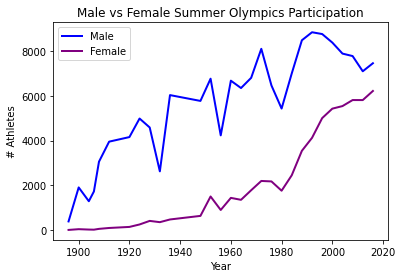

```python
plt.plot(male_summer.Year, male_summer.Male, marker='', color='blue', linewidth=2, label='Male')
plt.plot(female_summer.Year, female_summer.Female, marker='', color='purple', linewidth=2, label='Female')
plt.legend(loc=2)
plt.xlabel("Year")
plt.ylabel("# Athletes")
plt.title("Male vs Female Summer Olympics Participation")
```

This graph is much easier to read now and its easy to tell that there was a huge gap in gender participation in the early years but since the 1980 there has been a steady climb in female participants so eventually this should become very close.

Now I will do the same for the Winter games.

```python
male_winter = pysqldf('''SELECT Year,
                        CAST(SUM(CASE WHEN Sex = 'M' THEN 1 ELSE 0 END) AS INT) Male
                        FROM winter_games
                        GROUP BY year''')

female_winter = pysqldf('''SELECT year,
                            CAST(SUM(CASE WHEN Sex = 'F' THEN 1 ELSE 0 END) AS INT) Female
                            FROM winter_games
                            GROUP BY year''')
```

```python
male_winter.tail()
```

|  | Year | Male |
| --- | --- | --- |
| 17 | 1998 | 2221 |
| 18 | 2002 | 2527 |
| 19 | 2006 | 2625 |
| 20 | 2010 | 2555 |
| 21 | 2014 | 2868 |

```python
female_winter.tail()
```

|  | Year | Female |
| --- | --- | --- |
| 17 | 1998 | 1384 |
| 18 | 2002 | 1582 |
| 19 | 2006 | 1757 |
| 20 | 2010 | 1847 |
| 21 | 2014 | 2023 |

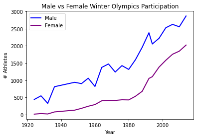

```python
plt.plot(male_winter.Year, male_winter.Male, marker='', color='blue', linewidth=2, label='Male')
plt.plot(female_winter.Year, female_winter.Female, marker='', color='purple', linewidth=2, label='Female')
plt.legend(loc=2)
plt.xlabel("Year")
plt.ylabel("# Athletes")
plt.title("Male vs Female Winter Olympics Participation")
```

# Question 2:

Question 2: Countries with the most medals and how they compare between Summer and Winter

```python
top10_countries_total = pysqldf('''SELECT Team, NOC, COUNT(Medal) Total_Medals
                                    FROM athlete_events
                                    GROUP BY Team
                                    ORDER BY COUNT(Medal) DESC
                                    LIMIT 10''')

top10_countries_total
```

|  | Team | NOC | Total_Medals |
| --- | --- | --- | --- |
| 0 | United States | USA | 5219 |
| 1 | Soviet Union | URS | 2451 |
| 2 | Germany | GER | 1984 |
| 3 | Great Britain | GBR | 1673 |
| 4 | France | FRA | 1550 |
| 5 | Italy | ITA | 1527 |
| 6 | Sweden | SWE | 1434 |
| 7 | Australia | AUS | 1306 |
| 8 | Canada | CAN | 1243 |
| 9 | Hungary | HUN | 1127 |

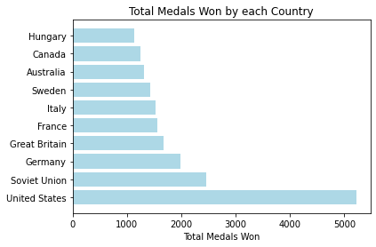

```python
plt.barh(top10_countries_total.Team, top10_countries_total.Total_Medals, color='lightblue')
plt.xlabel('Total Medals Won')
plt.title('Total Medals Won by each Country')
```

```python
top10_countries_summer = pysqldf('''SELECT Team, NOC, COUNT(Medal) Total_Medals
                                    FROM summer_games
                                    GROUP BY Team
                                    ORDER BY COUNT(Medal) DESC
                                    LIMIT 10''')
top10_countries_summer
```

|  | Team | NOC | Total_Medals |
| --- | --- | --- | --- |
| 0 | United States | USA | 4686 |
| 1 | Soviet Union | URS | 2061 |
| 2 | Germany | GER | 1687 |
| 3 | Great Britain | GBR | 1598 |
| 4 | France | FRA | 1408 |
| 5 | Italy | ITA | 1384 |
| 6 | Australia | AUS | 1290 |
| 7 | Hungary | HUN | 1123 |
| 8 | Sweden | SWE | 1006 |
| 9 | Russia | RUS | 894 |

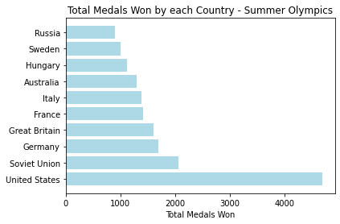

```python
plt.barh(top10_countries_summer.Team, top10_countries_summer.Total_Medals, color='lightblue')
plt.xlabel('Total Medals Won')
plt.title('Total Medals Won by each Country - Summer Olympics')
```

```python
top10_countries_winter = pysqldf('''SELECT Team, NOC, COUNT(Medal) Total_Medals
                                    FROM winter_games
                                    GROUP BY Team
                                    ORDER BY COUNT(Medal) DESC
                                    LIMIT 10''')
top10_countries_winter
```

|  | Team | NOC | Total_Medals |
| --- | --- | --- | --- |
| 0 | Canada | CAN | 575 |
| 1 | United States | USA | 533 |
| 2 | Norway | NOR | 443 |
| 3 | Sweden | SWE | 428 |
| 4 | Finland | FIN | 426 |
| 5 | Soviet Union | URS | 390 |
| 6 | Germany | GER | 297 |
| 7 | Austria | AUT | 244 |
| 8 | Russia | RUS | 216 |
| 9 | Switzerland | SUI | 183 |

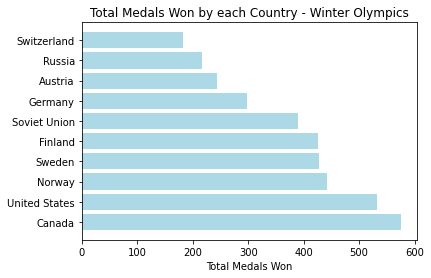

```python
plt.barh(top10_countries_winter.Team, top10_countries_winter.Total_Medals, color='lightblue')
plt.xlabel('Total Medals Won')
plt.title('Total Medals Won by each Country - Winter Olympics')
```

# Question 3:

Question 3: Age distribution, oldest and youngest Olympians

```python
ages = pysqldf('''SELECT Age, COUNT(Age) Count_Of_Ages
                FROM athlete_events
                GROUP BY Age''')

ages
```

|  | Age | Count_Of_Ages |
| --- | --- | --- |
| 0 | NaN | 0 |
| 1 | 10.0 | 1 |
| 2 | 11.0 | 13 |
| 3 | 12.0 | 39 |
| 4 | 13.0 | 187 |
| ... | ... | ... |
| 70 | 81.0 | 2 |
| 71 | 84.0 | 1 |
| 72 | 88.0 | 3 |
| 73 | 96.0 | 1 |
| 74 | 97.0 | 1 |

75 rows × 2 columns

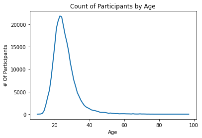

```python
plt.plot(ages.Age, ages.Count_Of_Ages, marker='', linewidth = 2)
plt.xlabel('Age')
plt.ylabel('# Of Participants')
plt.title('Count of Participants by Age')
```

```python
avg_age = pysqldf('''SELECT AVG(Age) Average_Age
                FROM athlete_events''')

avg_age
```

|  | Average_Age |
| --- | --- |
| 0 | 25.556898 |

```python
pip install nbconvert
```

```python
import nbconvert
```